[Home](https://twitter.com/CanHolyavkin) | [Other Posts](https://twitter.com/CanHolyavkin) | [Contact](https://twitter.com/CanHolyavkin)

# R’da text (.txt) dosyası nasıl içeri aktarılır?

R’a dosya aktarlarında, daha fazla veriyi daha küçük boyutta saklayabildiği için genellikle düz text formatındaki dosyaları tercih edilir. Bu text dosyaları kendi içinde font ve stil gibi özellikler barındırmasa da yapısal barındırabilir. Veriler birbirinden farklı karakterler ile (tab, noktalı virgül veya boşluk) ayrılmış olabilir. Başlık satırı veya eksik veriler içerebilir.

Çeşitli yolları olsa da, genellikle text dosyalarını 2 farklı komut ile R’ya aktarabilirsiniz. Bunlardan biri `readLines()`, diğeri ise `read.table()`‘dır.

> **Not:** readLines ve read.table dışında, `read.csv()` ve `read.delim()` gibi komutlar da bulunmaktadır. Ancak bu komutlar, yukarıda bahsettiğim komutların belli dosya formatlarına göre özelleşmiş halleridir. Uygun parametreleri kullanarak tüm text dosyalarını `readLines()` ve `read.table()` komutları ile içeri aktarabilirsiniz.

# readLines()

Bu komut dokümandaki her satırı tek tek okur. Her bir satır, içinde ne olursa olsun (ister tab, ister virgül, isterse smiley) tek bir nesne olarak içeri aktarılır. Genellikle her satırda bir nesnenin olduğu dosyaları içeri aktarmak için yararlıdır. Aynı zamanda `read.table()` komutunun hata verdiği durumlarda, dosyayı kontrol etmek için de kullanılır. Şimdi isimler_1.txt adlı text dosyasını sisteme `readLines()` komutu ile yükleyelim.

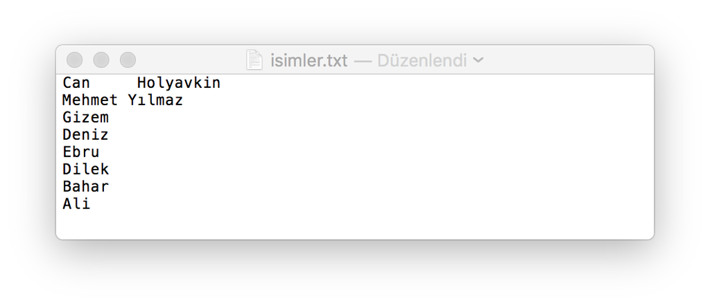

Aşağıdaki komut ile dosyamızı içeri aldığımızda şu verileri görürüz.

```r
ad1  <- readLines("isimler_1.txt")
print(ad1)
```

```
## [1] "Can\tHolyavkin" "Mehmet Yılmaz"  "Gizem"          "Deniz"
## [5] "Ebru"           "Dilek"          "Bahar"          "Ali"
```

Görüldüğü gibi `readLines()` komutu, her satırdaki değeri bir bütün gibi içeri aktardı. İlk satırdaki ad ve soyad arasındaki tab karakterini `\t` ile, ikinci satırdaki boşluk karakterini de aynı boşluk olarak gösterdi.

`readLines()` komutunun beraberinde kullanıldığı bir çok parametre bulunmaktadır. Bu parametreler ile dosya içinde maksimum kaç satır okunabileceği ve benzeri kısıtlamalar getirilebilir. Bu özelliklerden ilerideki yazılarda bahsedeceğiz.

# read.table()

Dosya içe aktarımlarının çoğunda bu komut kullanılır. Ayrılmış (tab seperated, comma separated, csv vb.) dosyaların, tablo halinde R sistemine aktarılmasında çok kullanışlıdır. Çok sayıda parametre ile txt dosyası formatında ne var ne yoksa esnek olarak içeri aktarılabilir.

Şimdi `read.table()` komutunu kullanarak isimler_2.txt dosyasını içeri aktaralım.

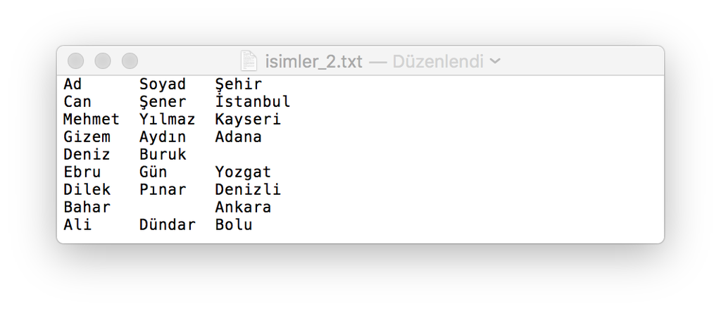

```r
ad2 <- read.table("isimler_2.txt", header=TRUE, sep="\t", fill=TRUE, stringsAsFactors=FALSE)
print(ad2)
```

```
##       Ad  Soyad    Şehir
## 1    Can  Şener İstanbul
## 2 Mehmet Yılmaz  Kayseri
## 3  Gizem  Aydın    Adana
## 4  Deniz  Buruk
## 5   Ebru    Gün   Yozgat
## 6  Dilek  Pınar  Denizli
## 7  Bahar          Ankara
## 8    Ali Dündar     Bolu
```

Bu sefer kod içerisinde header ve sep gibi bazı parametreler kullandık. Bu parametreler fonksiyonu yönlendirerek , ilgili fonksiyonun doğru şekilde yerine getirilmesi için kullanılır.

## header parametresi:

Dosyanın ilk satırının başlık olduğunu bildiğimiz için `header = TRUE` ifadesini ekledik. Eğer bu ifadeyi eklemeseydik veya `header = FALSE` olarak belirtseydik, R dosyanın ilk satırını (Ad Soyad Şehir) başlık olarak değil, bir veri olarak içeri aktaracaktı.

## sep parametresi:

Kullanılan bir diğer parametre `sep = "\t"` , dosya içinde aynı satırda yer alan verilerin birbirinden hangi karakter ile ayrıldığını gösterir. Bizim dosyamızda ad ve soyad “tab” karakteri ile ayrıldığı için bunu gösteren ifade olan `\t` yazdık. Eğer veriler boşluk ile ayrılsaydı `sep = " "` (tırnak içinde boşluk); eğer noktalı virgül ile ayrılsaydı `sep = ";"` şeklinde belirtecektik.

## fill parametresi:

Dikkat ettiyseniz, içeri aktardığımız dosyaların bir kısmında soyad ve şehir bilgisi yer almıyor. Kullandığımız `read.table()` komutu, içeri aktarılan verilerle bir tablo oluşturma (data.frame) davranışı içerdiğinden tüm kolonların dolu olacağını kabul eder. Bazı kolonlarda eksik veri olduğunda aşağıdaki hatayı verebilir.

`Error in scan(file = file, what = what, sep = sep, quote = quote, dec = dec, :` `4 . dize 3 öğeye sahip değil`

Veriye baktığımızda 4. satırda yer alan dizede şehir kolonunun (3. öğe) veriye sahip olmadığını görürüz. Bu durumda, `read.table()` komutuna eksik verileri `NA` (eksik veri değeri) değeri ile doldurmasını `fill=TRUE` parametresi ile iletebiliriz. Eğer verinizde eksik yoksa bu parametreyi kullanmak zorunda değilsiniz.

## stringsAsFactors parametresi:

Bu parametreyi anlamak için R’daki faktör kavramından bahsetmek gerek. R, nümerik olmayan karakterleri (örn: Can, İstanbul gibi), faktör tipine dönüştürerek içeri alma eğilimindedir. Faktörler, kategorik değişkenleri belirler. Örneğin cinsiyet kolonunda “Erkek – Kadın – Diğer” gibi ifadeler faktör olarak adlandırılabilir. Faktörler o kolondaki kategorileri belirler ve ilgili kolona bu kategoriler dışında veri eklenemez. Bu durum bir anket hazırlarken belli bir soruya verilecek cevapları önceden belirlemenize benzer.

`stringsAsFactors=TRUE` demek, R’a şunu demekle eşdeğerdir:

> *Bu dosyayı içeri aktar. Kolona bu anda eklediğim veriler, o kolonda olabilecek tüm olası seçenekleri içerir. Bundan başka veriler eklenemez.*

Örneğin yukarıdaki dosya içeri aktarımında `stringsAsFactors=FALSE` yerine `stringsAsFactors=TRUE` olarak yazsaydık veriyi yine başarılı şekilde içeri aktarabilirdik.

```r
ad2 <- read.table("isimler_2.txt", header=TRUE, sep ="\t", fill=TRUE, stringsAsFactors=TRUE)
print(ad2)
```

```
##       Ad  Soyad    Şehir
## 1    Can  Şener İstanbul
## 2 Mehmet Yılmaz  Kayseri
## 3  Gizem  Aydın    Adana
## 4  Deniz  Buruk
## 5   Ebru    Gün   Yozgat
## 6  Dilek  Pınar  Denizli
## 7  Bahar          Ankara
## 8    Ali Dündar     Bolu
```

Ancak, bu satırlardan birini değiştirmek isteseydik hata alırdık.

```r
ad2[1,1] <- "Ekrem"
```

[output not shown]

> *Verileri içe aktarırken bana hiç Ekrem’den bahsetmedin. Ad kolonuna gelebilecek isimler belliydi. Bu isim nereden çıktı? Ben tanımam Ekrem’i falan. Onun yerine NA değeri ekliyorum.*

Yukarıdaki örnekte, dosya içeri aktarımında `stringsAsFactors=TRUE` değeri yüzünden, R’ın nümerik olmayan kolonları kategori olarak kabul etti. Yani, Ad kolonunda olabilecek tüm seçenekler, ilk başta adları girilen isimlerden (Can, Mehmet, Gizem …) ibaret oldu. Diğer bir deyişle ilgili kolona gelecek veriler çoktan seçmeli hale getirdik. Bu faktörler dışında bir değer girildiğinde, yeni veri (“Ekrem”) varolan kategoriler arasında olmadığı için hata aldık. Ancak, “Ekrem” yerine “Dilek” eklemek isteseydik, hata vermeyecekti. Çünkü “Dilek” ilk girilen veriler arasında bulunuyordu.

Bu parametreyi kod içinde yazılmadığında varsayılan değer olarak `TRUE` değerini alır. Eğer içeri aktaracağını verilere sonradan ekleme yapmanız gerekecekse bu değeri `FALSE` olarak çevirebilirsiniz.

**Can Holyavkin**

E-posta | [Linkedin](https://www.linkedin.com/in/can-holyavkin/) | [Twitter](https://twitter.com/CanHolyavkin)